# stack-overflow-survey

```python
import pandas as pd
import numpy as np
import matplotlib.pyplot as plt
import seaborn as sns
%matplotlib inline
```

```python
df  =  pd.read_csv('survey_results_public.csv')
```

```python
df.columns
```

```
Index(['Respondent', 'Hobby', 'OpenSource', 'Country', 'Student', 'Employment',
       'FormalEducation', 'UndergradMajor', 'CompanySize', 'DevType',
       ...
       'Exercise', 'Gender', 'SexualOrientation', 'EducationParents',
       'RaceEthnicity', 'Age', 'Dependents', 'MilitaryUS', 'SurveyTooLong',
       'SurveyEasy'],
      dtype='object', length=129)
```

# Around 81% people has coding as their hobby

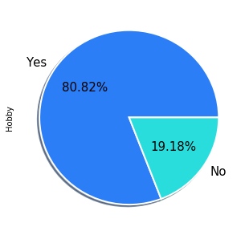

```python
plt.figure(figsize = (5,5))
df.Hobby.value_counts().plot.pie(autopct = "%1.2f%%",colors = sns.color_palette("rainbow",5),fontsize=15,wedgeprops={"linewidth":2,"edgecolor":"white"},shadow =True)
```

# Around 44% people contribute to open source projects

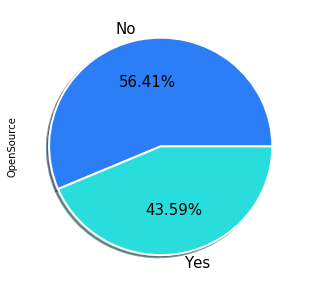

```python
plt.figure(figsize = (5,5))
df.OpenSource.value_counts().plot.pie(autopct = "%1.2f%%",colors = sns.color_palette("rainbow",5),fontsize=15,wedgeprops={"linewidth":2,"edgecolor":"white"},shadow =True)
```

```python
100 * df.Hobby.value_counts() / len(df.Hobby)
```

```
Yes    80.822417
No     19.177583
Name: Hobby, dtype: float64
```

```python
df.Hobby.value_counts()
```

```
Yes    79897
No     18958
Name: Hobby, dtype: int64
```

```python
df.Hobby.value_counts(normalize=True) * 100
```

```
Yes    80.822417
No     19.177583
Name: Hobby, dtype: float64
```

## Around 20,000 people of US gave the survey with 13,000 people of India being the second highest among the developers of the world.

```
United States         20309
India                 13721
Germany                6459
United Kingdom         6221
Canada                 3393
Russian Federation     2869
France                 2572
Brazil                 2505
Poland                 2122
Australia              2018
Name: Country, dtype: int64
```

```
Text(0.5,0,'Country names')
```

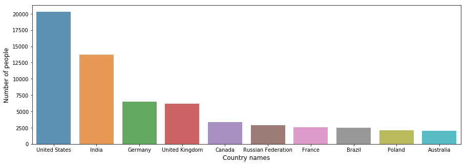

```python
countries=df.Country.value_counts()[:10]
print(countries)
plt.figure(figsize = (15,5))
sns.barplot(x = countries.index, y = countries.values, alpha = 0.8)
plt.ylabel('Number of people', fontsize=12)
plt.xlabel('Country names', fontsize=12)
```

```python
#for i in df.DevType:
#    print(i)
```

```python
len(df.DevType.unique())
```

```
9569
```

```python
y=[]
for i in df.DevType:
    for j in (str(i).split(';')):
        y.append(j)
```

```python
y=pd.Series(y)
y=y[y!='nan']
y.value_counts()
```

```
Back-end developer                               53300
Full-stack developer                             44353
Front-end developer                              34822
Mobile developer                                 18804
Desktop or enterprise applications developer     15807
Student                                          15732
Database administrator                           13216
Designer                                         12019
System administrator                             10375
DevOps specialist                                 9549
Data or business analyst                          7559
Data scientist or machine learning specialist     7088
QA or test developer                              6194
Engineering manager                               5256
Embedded applications or devices developer        4819
Game or graphics developer                        4642
Product manager                                   4316
Educator or academic researcher                   3641
C-suite executive (CEO, CTO, etc.)                3491
Marketing or sales professional                   1122
dtype: int64
```

# Usually people spend around 9-12 hours on their PC

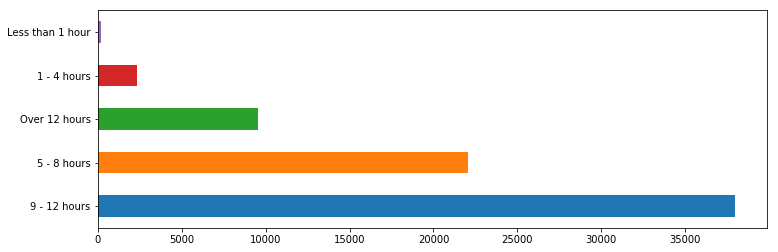

```python
plt.figure(figsize = (12,4))
df.HoursComputer.value_counts().plot(kind='barh')
```

## Back-end developer is the most common and highly opted developer type with full-stack developer and front-end developer being the second and third highest respectively

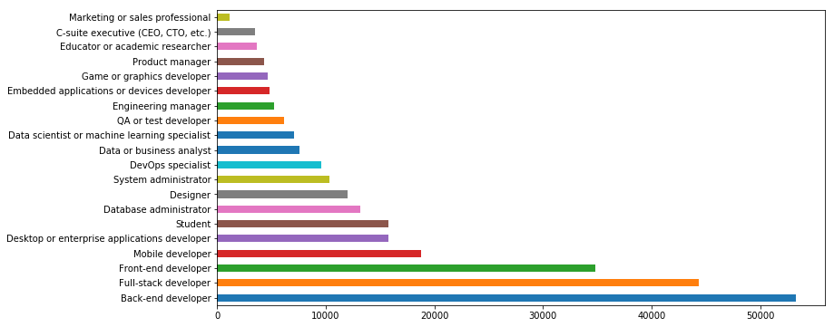

```python
plt.figure(figsize = (12,6))
pd.Series(y).value_counts().plot(kind='barh')
```

```python
y.value_counts() / len(df.DevType) * 100
```

```
Back-end developer                               53.917354
Full-stack developer                             44.866724
Front-end developer                              35.225330
Mobile developer                                 19.021800
Desktop or enterprise applications developer     15.990086
Student                                          15.914218
Database administrator                           13.369076
Designer                                         12.158212
System administrator                             10.495170
DevOps specialist                                 9.659602
Data or business analyst                          7.646553
Data scientist or machine learning specialist     7.170098
QA or test developer                              6.265743
Engineering manager                               5.316878
Embedded applications or devices developer        4.874817
Game or graphics developer                        4.695767
Product manager                                   4.365991
Educator or academic researcher                   3.683172
C-suite executive (CEO, CTO, etc.)                3.531435
Marketing or sales professional                   1.134996
dtype: float64
```

```python
#devtypes = ['Back-end developer', 'C-suite executive (CEO, CTO, etc.)', 'Data or business analyst', 'Data scientist or machine learning specialist', 'Database administrator', 'Designer', 'Desktop or enterprise applications developer', 'DevOps specialist', 'Educator or academic researcher', 'Embedded applications or devices developer', 'Engineering manager', 'Front-end developer', 'Full-stack developer', 'Game or graphics developer', 'Marketing or sales professional', 'Mobile developer', 'Product manager', 'QA or test developer', 'Student', 'System administrator', 'None of the above']
```

```python
# dev={}
# for i in df.DevType:
#     for j in (str(i).split(';')):
#         if j in dev.keys():
#             dev[j] += 1
#         else:
#             dev[j] = 1
```

```python
# del dev['nan']
```

```python
# dev
```

```python
# pd.Series(y).value_counts() / len(y) * 100
```

# Maximum age group of people who filled the survey is of 25-34 years old

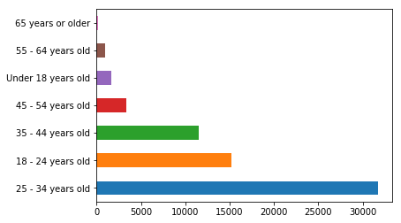

```python
df.Age.value_counts().plot(kind="barh")
```

## 26% people are currently enrolled in some degree program who filled the survey

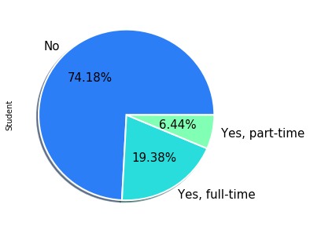

```python
plt.figure(figsize = (5,5))
df.Student.value_counts().plot.pie(autopct = "%1.2f%%",colors = sns.color_palette("rainbow",5),fontsize=15,wedgeprops={"linewidth":2,"edgecolor":"white"},shadow =True)
```

# Current Employment status of most of the people was employed for full-time

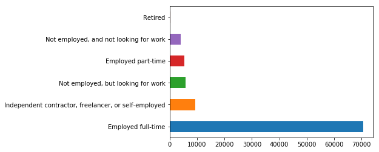

```python
df.Employment.value_counts().plot(kind="barh")
```

## Maximum people have years of coding including any education period for around 3-5 years

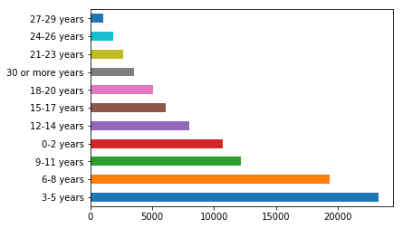

```python
df.YearsCoding.value_counts().plot(kind="barh")
```

## While max. people coding professionally in any organisation is lower : 0-2 years

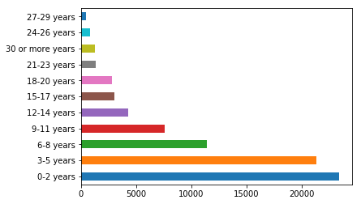

```python
df.YearsCodingProf.value_counts().plot(kind="barh")
```

```python
#df.LanguageWorkedWith.value_counts().plot(kind="bar")
```

```python
langs_worked=[]
for i in df.LanguageWorkedWith:
    for j in (str(i).split(';')):
        langs_worked.append(j)
```

```python
langs_worked=pd.Series(langs_worked)
langs_worked=langs_worked[langs_worked!='nan']
langs_worked.value_counts()
```

```
JavaScript              54686
HTML                    53628
CSS                     50979
SQL                     44670
Java                    35521
Bash/Shell              31172
Python                  30359
C#                      26954
PHP                     24071
C++                     19872
C                       18042
TypeScript              13626
Ruby                     7911
Swift                    6310
Assembly                 5760
Go                       5532
Objective-C              5510
VB.NET                   5254
R                        4813
Matlab                   4564
VBA                      3810
Kotlin                   3508
Scala                    3420
Groovy                   3373
Perl                     3280
Visual Basic 6           3087
Lua                      2733
CoffeeScript             2603
Delphi/Object Pascal     2025
Haskell                  1961
Rust                     1857
F#                       1115
Clojure                  1032
Erlang                    886
Cobol                     590
Ocaml                     470
Julia                     430
Hack                      254
dtype: int64
```

## Most people have worked with the languages: Javascript, HTML, CSS, SQL and JAVA

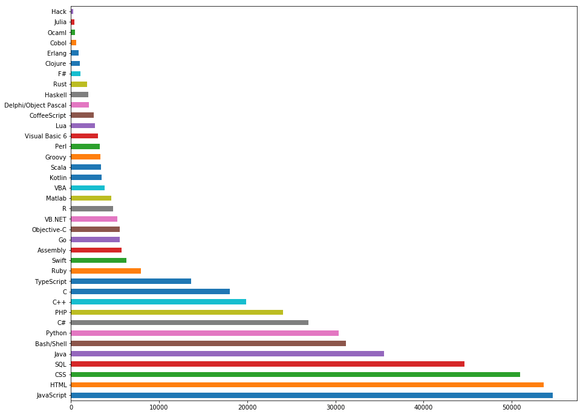

```python
plt.figure(figsize = (15,12))
langs_worked.value_counts().plot(kind='barh')
#plt.gca().invert_yaxis()
```

## Most people desire languages: Javascript at the top and theey python being second highest. It shows people currently working with python are less yet they desire to work with it

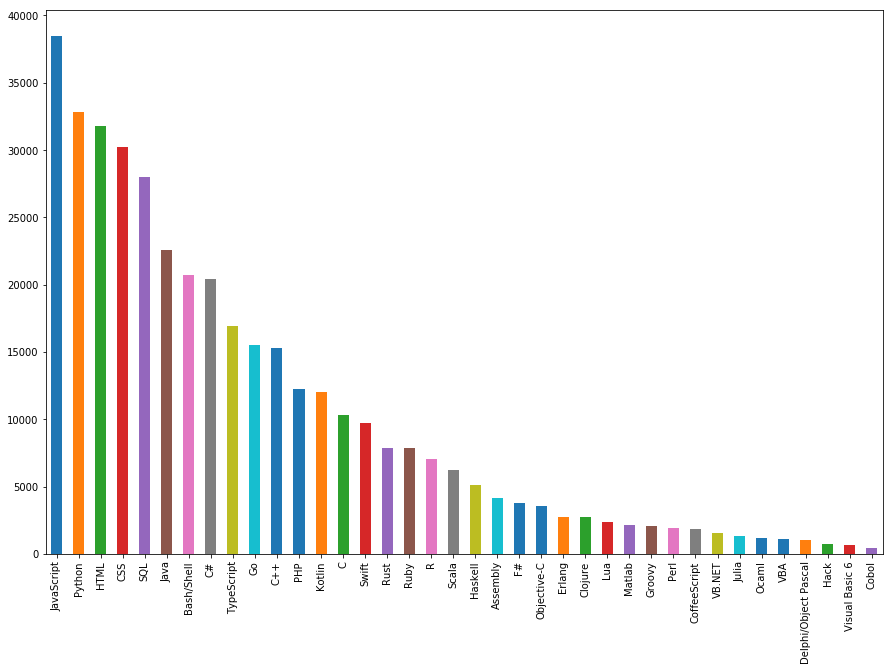

```python
langs_desired=[]
for i in df.LanguageDesireNextYear:
    for j in (str(i).split(';')):
        langs_desired.append(j)
langs_desired=pd.Series(langs_desired)
langs_desired=langs_desired[langs_desired!='nan']
#langs_desired.value_counts()
plt.figure(figsize = (15,10))
langs_desired.value_counts().plot(kind='bar')
```

# MySQL is the database most worked with

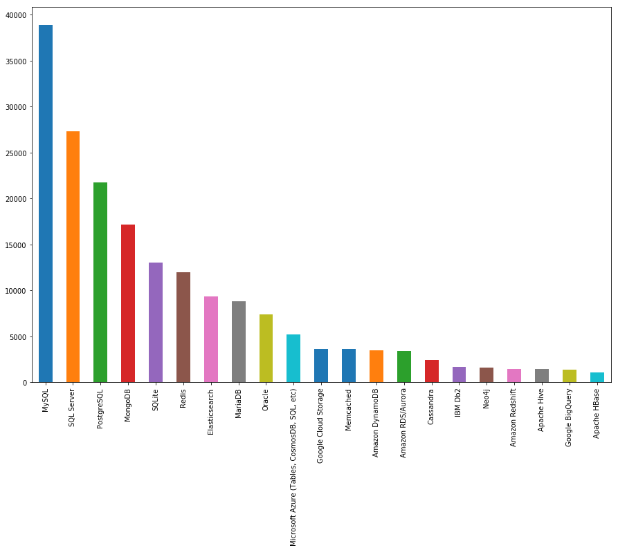

```python
data_worked=[]
for i in df.DatabaseWorkedWith:
    for j in (str(i).split(';')):
        data_worked.append(j)
data_worked=pd.Series(data_worked)
data_worked=data_worked[data_worked!='nan']
plt.figure(figsize = (15,10))
data_worked.value_counts().plot(kind='bar')
```

## MySQL, MongoDB and PostgreSQL are the most desired database environments

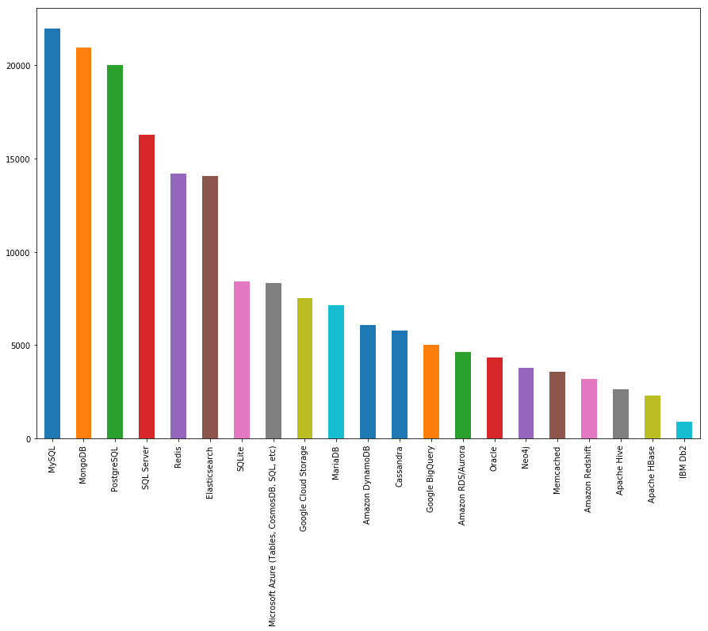

```python
data_desired=[]
for i in df.DatabaseDesireNextYear:
    for j in (str(i).split(';')):
        data_desired.append(j)
data_desired=pd.Series(data_desired)
data_desired=data_desired[data_desired!='nan']
plt.figure(figsize = (15,10))
data_desired.value_counts().plot(kind='bar')
```

# Most of the extensive development work is done on the Linux Platform

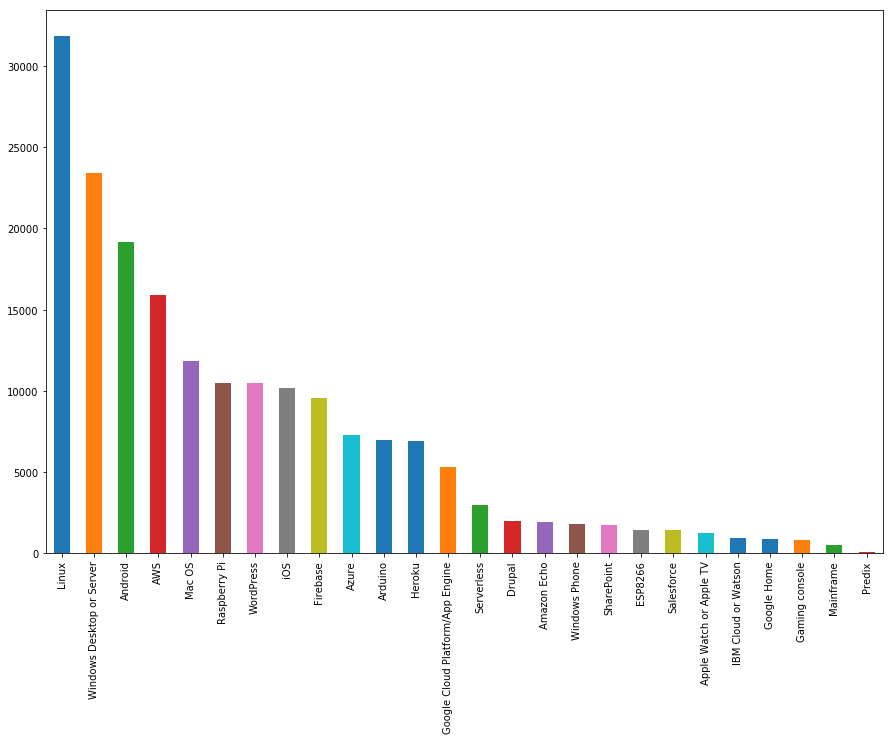

```python
platform_worked=[]
for i in df.PlatformWorkedWith:
    for j in (str(i).split(';')):
        platform_worked.append(j)
platform_worked=pd.Series(platform_worked)
platform_worked=platform_worked[platform_worked!='nan']
plt.figure(figsize = (15,10))
platform_worked.value_counts().plot(kind='bar')
```

## Most of the desired platform for extensive development work is also the Linux Platform

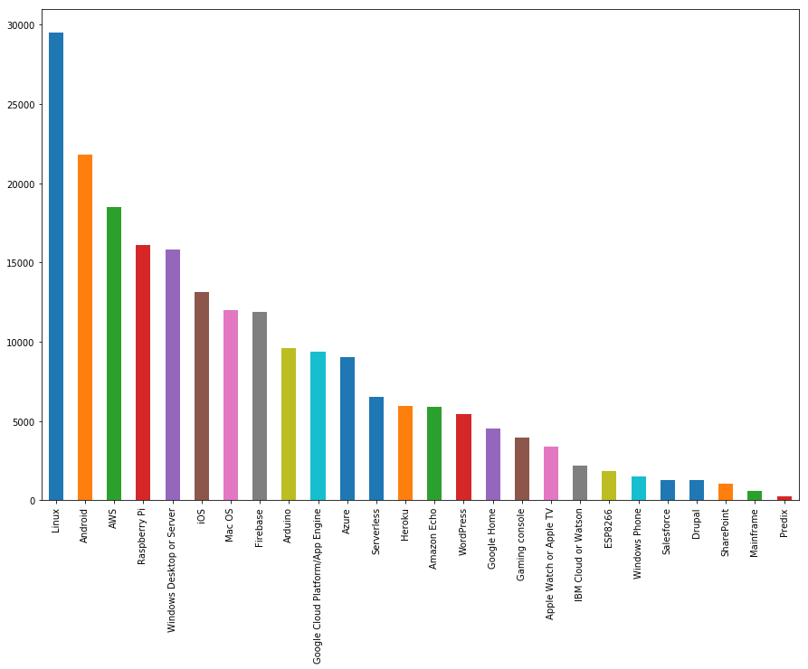

```python
platform_desired=[]
for i in df.PlatformDesireNextYear:
    for j in (str(i).split(';')):
        platform_desired.append(j)
platform_desired=pd.Series(platform_desired)
platform_desired=platform_desired[platform_desired!='nan']
plt.figure(figsize = (15,10))
platform_desired.value_counts().plot(kind='bar')
```

## Node.js is the leading framework to be worked for the extensive development work

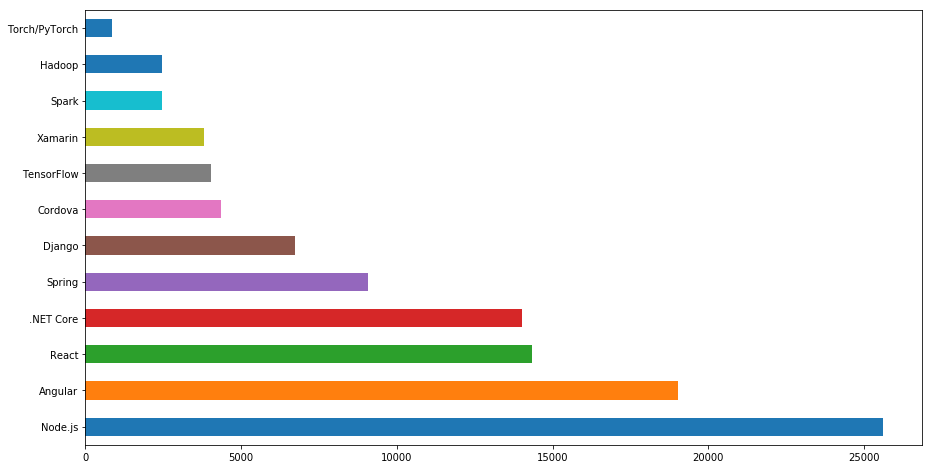

```python
framework_worked=[]
for i in df.FrameworkWorkedWith:
    for j in (str(i).split(';')):
        framework_worked.append(j)
framework_worked=pd.Series(framework_worked)
framework_worked=framework_worked[framework_worked!='nan']
plt.figure(figsize = (15,8))
framework_worked.value_counts().plot(kind='barh')
```

## Node.js and React are the framework and library that are desired for the extensive development work next year while people currently working on React are less

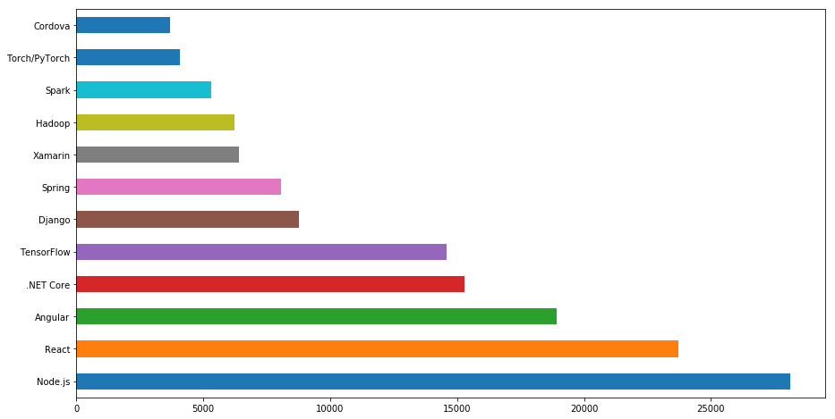

```python
framework_desired=[]
for i in df.FrameworkDesireNextYear:
    for j in (str(i).split(';')):
        framework_desired.append(j)
framework_desired=pd.Series(framework_desired)
framework_desired=framework_desired[framework_desired!='nan']
plt.figure(figsize = (15,8))
framework_desired.value_counts().plot(kind='barh')
```

## Visual Studio Code, Visual Studio and Notepad++ are the most popluar IDEs

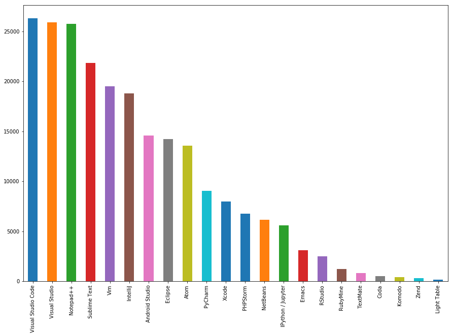

```python
ide=[]
for i in df.IDE:
    for j in (str(i).split(';')):
        ide.append(j)
ide=pd.Series(ide)
ide=ide[ide!='nan']
plt.figure(figsize = (15,10))
ide.value_counts().plot(kind='bar')
```

# Windows is the most preferable primary Operating System to be worked upon

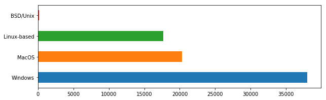

```python
os=[]
for i in df.OperatingSystem:
    for j in (str(i).split(';')):
        os.append(j)
os=pd.Series(os)
os=os[os!='nan']
plt.figure(figsize = (10,3))
os.value_counts().plot(kind='barh')
```

```python
for i in df.columns:
    print(i)
```

```
Respondent
Hobby
OpenSource
Country
Student
Employment
FormalEducation
UndergradMajor
CompanySize
DevType
YearsCoding
YearsCodingProf
JobSatisfaction
CareerSatisfaction
HopeFiveYears
JobSearchStatus
LastNewJob
AssessJob1
AssessJob2
AssessJob3
AssessJob4
AssessJob5
AssessJob6
AssessJob7
AssessJob8
AssessJob9
AssessJob10
AssessBenefits1
AssessBenefits2
AssessBenefits3
AssessBenefits4
AssessBenefits5
AssessBenefits6
AssessBenefits7
AssessBenefits8
AssessBenefits9
AssessBenefits10
AssessBenefits11
JobContactPriorities1
JobContactPriorities2
```

[output cut: 74 more lines]

```
WakeTime
HoursComputer
HoursOutside
SkipMeals
ErgonomicDevices
Exercise
Gender
SexualOrientation
EducationParents
RaceEthnicity
Age
Dependents
MilitaryUS
SurveyTooLong
SurveyEasy
```

## Algorithms making decisions and AI surpassing human Intelligence considered the most important factors for AI being dangerous

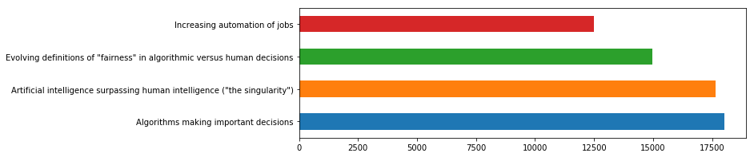

```python
plt.figure(figsize = (10,3))
df.AIDangerous.value_counts().plot(kind="barh")
```

# Increasing automation of jobs is considered the most exciting aspect of AI

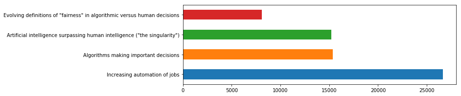

```python
plt.figure(figsize = (10,3))
df.AIInteresting.value_counts().plot(kind="barh")
```

# Developers or people creating AI are considered responsible for ramifications of increasing AI technology

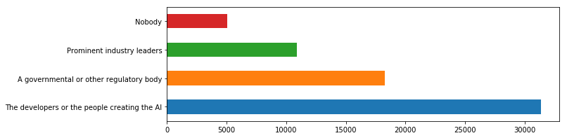

```python
plt.figure(figsize = (10,3))
df.AIResponsible.value_counts().plot(kind="barh")
```

## People are excited about the possibilities rather than worried about the dangers of AI

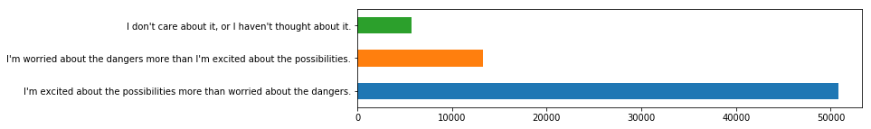

```python
plt.figure(figsize = (10,2))
df.AIFuture.value_counts().plot(kind="barh")
```

# People are very likely to recommend Stack Overflow

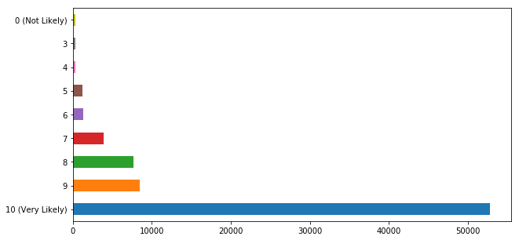

```python
plt.figure(figsize = (10,5))
df.StackOverflowRecommend.value_counts()[:9].plot(kind="barh")
```

```python
df.StackOverflowRecommend.value_counts(normalize = True) * 100
```

```
10 (Very Likely)    69.016460
9                   11.047340
8                   10.023664
7                    5.081776
6                    1.725738
5                    1.546628
4                    0.409209
3                    0.384369
0 (Not Likely)       0.352992
2                    0.249709
1                    0.162115
Name: StackOverflowRecommend, dtype: float64
```

```python
df.StackOverflowRecommend.value_counts()
```

```
10 (Very Likely)    52790
9                    8450
8                    7667
7                    3887
6                    1320
5                    1183
4                     313
3                     294
0 (Not Likely)        270
2                     191
1                     124
Name: StackOverflowRecommend, dtype: int64
```

```python
df.StackOverflowRecommend.value_counts() / len(df) * 100
```

```
10 (Very Likely)    53.401447
9                    8.547873
8                    7.755804
7                    3.932022
6                    1.335289
5                    1.196702
4                    0.316625
3                    0.297405
0 (Not Likely)       0.273127
2                    0.193212
1                    0.125436
Name: StackOverflowRecommend, dtype: float64
```

## Most of the people either visit Stack Overflow daily or visit multiple times per day

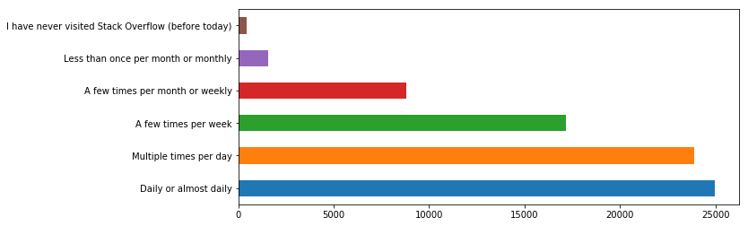

```python
plt.figure(figsize = (10,4))
df.StackOverflowVisit.value_counts().plot(kind="barh")
```

# Around 87.5% people have accounts on Stack Overflow

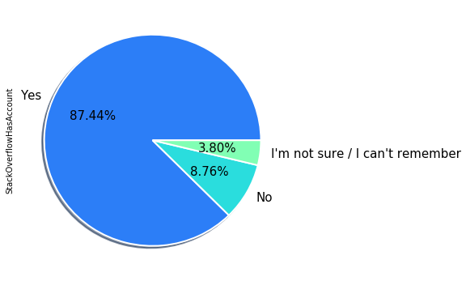

```python
plt.figure(figsize = (6,6))
df.StackOverflowHasAccount.value_counts().plot.pie(autopct = "%1.2f%%",colors = sns.color_palette("rainbow",5),fontsize=15,wedgeprops={"linewidth":2,"edgecolor":"white"},shadow =True)
```

## People tend to participate in Q&A section less than once per month or monthly

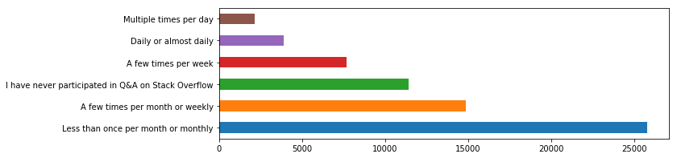

```python
plt.figure(figsize = (10,3))
df.StackOverflowParticipate.value_counts().plot(kind="barh")
```

# 55.5% people consider themselves a member of stack overflow community

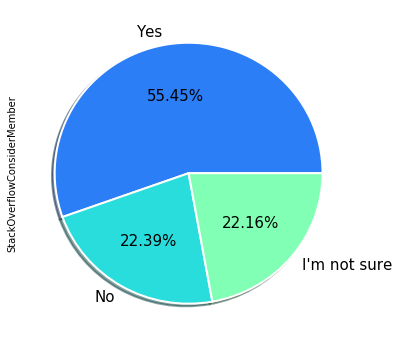

```python
plt.figure(figsize = (6,6))
df.StackOverflowConsiderMember.value_counts().plot.pie(autopct = "%1.2f%%",colors = sns.color_palette("rainbow",5),fontsize=15,wedgeprops={"linewidth":2,"edgecolor":"white"},shadow =True)
```